# A Thiopurine-like Mutagenic Process Defines TGCT Subtypes

Tongwu Zhang

2025-11-17

## 1 Overview

This R Markdown document reproduces the main analyses and figures for TCGA-TGCT WGS dataset

Manuscript title: A Thiopurine-like Mutagenic Process Defines TGCT Subtype

## 2 Fig. 4: Impact of Thiopurine-Associated Mutational Signature SBS87 on Tumor Latency and Telomere Length in TGCTs.

## 3 Load Required Libraries and Set Plotting Styles

(You may need to install some packages if missing)

```r
source('functions/Sherlock_functions.R')

set_wd()
```

```
## [1] "/Users/zhangt8/NIH-Work/Earl_Stadtman_Inverstigator/Projects/TCGA_TGCT/biowulf/Rmarkdown"
## [1] "ok"
```

```r
libztw()
pdfhr()
pdfhr2()

# Load R object WGS analysis results --------------------------------------

load('data/wgs_data.RData')
load('data/wgs_clinical.RData')
load('data/ngspurity_data.RData')
```

## 4 Fig. 4a

Comparison of estimated age of the most recent common ancestor (MRCA, left) and tumor latency (time from MRCA to diagnosis, right) between seminomas and non-seminomas. P-values from two-sided Wilcoxon rank-sum tests are shown above boxplots.

```r
load('../Chronological_timing_short.RData',verbose = T)
```

```
## Loading objects:
##   MRCAdata
##   subclonesTimeAbs
##   subclonesTimeAbsLinear
##   mrate
##   rateDeam
##   timingclass_groups
```

```r
library(ggpubr)
my_comparisons <- list(c("Seminoma", "Non-Seminoma"))

MRCAdata %>%
  filter(acceleration == "1x") %>%
  group_by(Subtype) %>%
  summarise(
    Latency = median(Latency, na.rm = T),
    Age = median(Age, na.rm = T),
    MRCA_age = median(MRCA_age, na.rm = T)
  )
```

```
## # A tibble: 2 × 4
##   Subtype      Latency   Age MRCA_age
##   <fct>          <dbl> <dbl>    <dbl>
## 1 Seminoma        4.90  35.2     34.3
## 2 Non-Seminoma    9.19  28.3     17.4
```

```r
MRCAdata %>%
  filter(acceleration == "1x") %>%
  filter(!is.na(Latency)) %>%
  left_join(ngspurity %>% select(Tumor_Barcode, BB_Purity)) %>%
  do(tidy(lm(Latency ~ Subtype + BB_Purity + Age, data = .)))
```

```
## # A tibble: 4 × 5
##   term                estimate std.error statistic   p.value
##   <chr>                  <dbl>     <dbl>     <dbl>     <dbl>
## 1 (Intercept)           -6.82     3.31       -2.06 0.0414
## 2 SubtypeNon-Seminoma    5.20     1.61        3.23 0.00163
## 3 BB_Purity              5.79     3.38        1.71 0.0893
## 4 Age                    0.290    0.0696      4.17 0.0000591
```

```r
my_comparisons <- list(c('Seminoma', 'Non-Seminoma'))

stat.test <- MRCAdata %>%
  filter(acceleration == "1x") %>%
  filter(!is.na(Latency)) %>%
  rstatix::wilcox_test(Latency ~ Subtype, comparisons = my_comparisons) %>%
  rstatix::add_xy_position(x = "Subtype") %>%
  mutate(
    myformatted.p = if_else(
      p < 0.001,
      sprintf("P = %.2e", p),
      sprintf("P = %.2f", p)
    )
  ) %>%
  mutate(Subtype = my_comparisons[[1]][1]) %>%
  mutate(col = if_else(p < 0.05, ncicolpal[1], 'black'))

stat.test
```

```
## # A tibble: 1 × 14
##   .y.     group1   group2     n1    n2 statistic       p y.position groups  xmin
##   <chr>   <chr>    <chr>   <int> <int>     <dbl>   <dbl>      <dbl> <list> <dbl>
## 1 Latency Seminoma Non-Se…    44    73     1100. 0.00449       36.1 <chr>      1
## # ℹ 4 more variables: xmax <dbl>, myformatted.p <chr>, Subtype <chr>, col <chr>
```

```r
p1 <- MRCAdata %>%
  filter(acceleration == "1x") %>%
  filter(!is.na(Latency)) %>%
  ggplot(aes(Subtype, Latency, fill = Subtype)) +
  geom_boxplot(
    width = 0.6,
    fill = "gray95",
    color = 'black',
    outlier.shape = 21,
    outlier.size = 0.8
  ) +
  ggbeeswarm::geom_quasirandom(
    pch = 21,
    size = 2.5,
    width = 0.2,
    color = "white",
    stroke = 0.2
  ) +
  labs(x = NULL, y = 'Latency, years before diagnosis') +
  scale_fill_manual(values = subtypecol) +
  scale_y_continuous(breaks = pretty_breaks(n = 7)) +
  theme_ipsum_rc(
    axis_text_size = 14,
    axis_title_just = 'm',
    axis_title_size = 16,
    grid = 'XY',
    ticks = T
  ) +
  panel_border(color = 'black') +
  theme(
    axis.text.x = element_blank(),
    panel.spacing.x = unit(0.4, 'cm'),
    axis.ticks.x = element_blank(),
    plot.margin = margin(4, 4, 4, 4),
    legend.position = 'bottom',
    legend.text = element_text(size = 14),
    legend.title = element_text(size = 14),
    strip.text.x = element_text(hjust = 0.5, face = 'bold', size = 5)
  ) +
  stat_pvalue_manual(data = stat.test, col = 'col', label = "myformatted.p") +
  scale_color_manual(values = c(ncicolpal[1], 'black')) +
  guides(color = 'none')


MRCAdata %>%
  filter(acceleration == "1x") %>%
  filter(!is.na(Latency)) %>%
  left_join(ngspurity %>% select(Tumor_Barcode, BB_Purity)) %>%
  do(tidy(lm(MRCA_age ~ Subtype + BB_Purity, data = .)))
```

```
## # A tibble: 3 × 5
##   term                estimate std.error statistic  p.value
##   <chr>                  <dbl>     <dbl>     <dbl>    <dbl>
## 1 (Intercept)            33.8       2.74    12.3   1.09e-22
## 2 SubtypeNon-Seminoma   -12.8       1.97    -6.51  2.07e- 9
## 3 BB_Purity              -1.92      4.63    -0.415 6.79e- 1
```

```r
my_comparisons <- list(c('Seminoma', 'Non-Seminoma'))

stat.test <- MRCAdata %>%
  filter(acceleration == "1x") %>%
  filter(!is.na(Latency)) %>%
  rstatix::wilcox_test(MRCA_age ~ Subtype, comparisons = my_comparisons) %>%
  rstatix::add_xy_position(x = "Subtype") %>%
  mutate(
    myformatted.p = if_else(
      p < 0.001,
      sprintf("P = %.2e", p),
      sprintf("P = %.2f", p)
    )
  ) %>%
  mutate(Subtype = my_comparisons[[1]][1]) %>%
  mutate(col = if_else(p < 0.05, ncicolpal[1], 'black'))

stat.test
```

```
## # A tibble: 1 × 14
##   .y.      group1   group2    n1    n2 statistic       p y.position groups  xmin
##   <chr>    <chr>    <chr>  <int> <int>     <dbl>   <dbl>      <dbl> <list> <dbl>
## 1 MRCA_age Seminoma Non-S…    44    73      2633 7.65e-9       58.7 <chr>      1
## # ℹ 4 more variables: xmax <dbl>, myformatted.p <chr>, Subtype <chr>, col <chr>
```

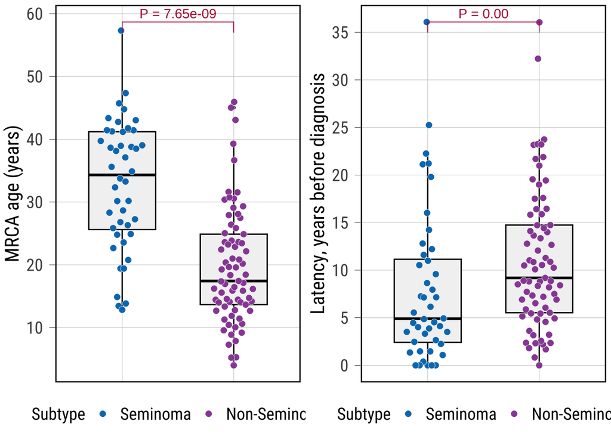

```r
p2 <- MRCAdata %>%
  filter(acceleration == "1x") %>%
  filter(!is.na(Latency)) %>%
  ggplot(aes(Subtype, MRCA_age, fill = Subtype)) +
  geom_boxplot(
    width = 0.6,
    fill = "gray95",
    color = 'black',
    outlier.shape = 21,
    outlier.size = 0.8
  ) +
  ggbeeswarm::geom_quasirandom(
    pch = 21,
    size = 2.5,
    width = 0.2,
    color = "white",
    stroke = 0.2
  ) +
  labs(x = NULL, y = 'MRCA age (years)') +
  scale_fill_manual(values = subtypecol) +
  scale_y_continuous(breaks = pretty_breaks(n = 7)) +
  theme_ipsum_rc(
    axis_text_size = 14,
    axis_title_just = 'm',
    axis_title_size = 16,
    grid = 'XY',
    ticks = T
  ) +
  panel_border(color = 'black') +
  theme(
    axis.text.x = element_blank(),
    panel.spacing.x = unit(0.4, 'cm'),
    axis.ticks.x = element_blank(),
    plot.margin = margin(4, 4, 4, 4),
    legend.position = 'bottom',
    legend.text = element_text(size = 14),
    legend.title = element_text(size = 14),
    strip.text.x = element_text(hjust = 0.5, face = 'bold', size = 5)
  ) +
  stat_pvalue_manual(data = stat.test, col = 'col', label = "myformatted.p") +
  scale_color_manual(values = c(ncicolpal[1], 'black')) +
  guides(color = 'none')


#ggsave(filename = 'MRCA_spgroup.pdf', width = 2, height = 6, device = cairo_pdf)

plot_grid(p2, p1, align = 'h', axis = 'tb', nrow = 1)
```

```r
ggsave(
  filename = 'MRCA_latency_spgroup.pdf',
  width = 4,
  height = 6,
  device = cairo_pdf
)
```

## 5 Fig. 4c

Linear regression analysis of mutational signatures associated with tumor latency in all TGCT samples, adjusted for tumor purity. FDR from Benjamini–Hochberg correction is shown, with FDR<0.05 thresholds marked by a red dashed line.

```r
load('data/Chronological_timing_short.RData', verbose = T)
```

```
## Loading objects:
##   MRCAdata
##   subclonesTimeAbs
##   subclonesTimeAbsLinear
##   mrate
##   rateDeam
##   timingclass_groups
```

```r
load('data/tgct_mutational_signatures.RData', verbose = T)
```

```
## Loading objects:
##   tgct_sbs96_profile
##   tgct_id83_profile
##   tgct_dbs78_profile
##   msa_sbs96_activity
##   msa_id83_activity
##   msa_dbs78_activity
##   tgct_activity_all
##   tgct_activity_all_obs
##   tgct_activity_all_ratio
##   tgct_sbs96_msa_decompsite
##   tgct_id83_msa_decompsite
##   tgct_dbs78_msa_decompsite
##   sigcol
##   tgct_tmb
```

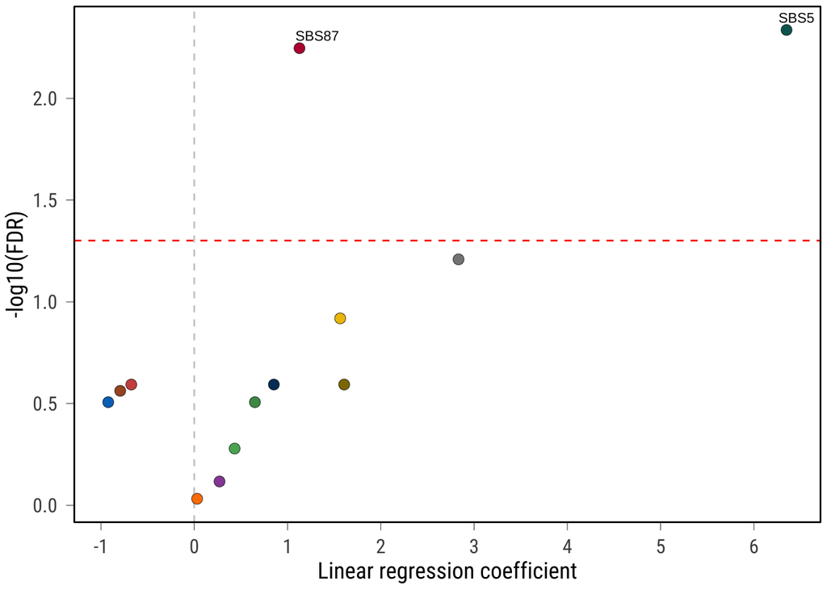

```r
load('data/ngspurity_data.RData')

tdata0 <- MRCAdata %>%
  filter(!is.na(Latency), acceleration == '1x') %>%
  select(Tumor_Barcode, Acc = acceleration, Latency) #Histology == "Adenocarcinoma"; acceleration == '1x'

tdata <- tgct_activity_all %>%
  pivot_longer(-Tumor_Barcode) %>%
  left_join(tdata0) %>%
  left_join(wgs_data %>% select(Tumor_Barcode, Subtype)) %>%
  left_join(ngspurity %>% select(Tumor_Barcode, BB_Purity)) %>%
  filter(!is.na(Latency))

tresult_all <- tdata %>%
  mutate(value = log2(value + 1)) %>%
  group_by(name) %>%
  do(tresult = safely(lm)(Latency ~ value + BB_Purity + Subtype, data = .)) %>%
  mutate(tresult_null = map_lgl(tresult['result'], is.null)) %>%
  filter(!tresult_null) %>%
  mutate(fit = list(tidy(tresult[['result']]))) %>%
  select(name, fit) %>%
  unnest(cols = c(fit)) %>%
  ungroup() %>%
  filter(term == 'value') %>%
  arrange(p.value) %>%
  mutate(FDR = p.adjust(p.value, method = 'BH'))

# tresult_all <- tdata %>%
#   group_by(name,Subtype) %>%
#   do(tresult = safely(cor.test)(.$Latency,log2(.$value+1))) %>%
#   mutate(tresult_null = map_lgl(tresult['result'], is.null)) %>%
#   filter(!tresult_null) %>%
#   mutate(fit = list(tidy(tresult[['result']]))) %>%
#   select(Subtype,name,fit) %>%
#   unnest(cols = c(fit)) %>%
#   ungroup() %>%
#   group_by(Subtype) %>%
#   mutate(FDR=p.adjust(p.value,method='fdr')) %>%
#   arrange(FDR)

# tresult_all <- tdata %>%
#   group_by(name) %>%
#   do(tresult = safely(cor.test)(.$Latency,.$value)) %>%
#   mutate(tresult_null = map_lgl(tresult['result'], is.null)) %>%
#   filter(!tresult_null) %>%
#   mutate(fit = list(tidy(tresult[['result']]))) %>%
#   select(name,fit) %>%
#   unnest(cols = c(fit)) %>%
#   ungroup() %>%
#   arrange(p.value) %>%
#   mutate(FDR=p.adjust(p.value,method='BH'))

tresult_all %>%
  ggplot(aes((estimate), -log10(FDR), fill = name)) +
  geom_hline(yintercept = -log10(0.05), linetype = 2, col = 'red', size = 0.5) +
  geom_vline(xintercept = 0, linetype = 2, col = '#cccccc', size = 0.5) +
  geom_point(pch = 21, stroke = 0.2, size = 3) +
  scale_fill_manual(values = sigcol) +
  scale_x_continuous(breaks = pretty_breaks(n = 7)) +
  ggrepel::geom_text_repel(
    data = tresult_all %>% filter(FDR < 0.05),
    aes(label = name),
    max.overlaps = 30,
    size = 3
  ) +
  labs(
    x = 'Linear regression coefficient',
    y = '-log10(FDR)',
    fill = 'Signature'
  ) +
  guides(fill = 'none') +
  theme_ipsum_rc(
    base_size = 12,
    axis_title_just = 'm',
    axis_title_size = 14,
    grid = F,
    ticks = T
  ) +
  theme(plot.margin = margin(4, 4, 4, 4)) +
  panel_border(color = 'black', size = 0.5) +
  coord_cartesian(clip = 'off')
```